# Analysis code for ‘Life history traits, pace-of-life and dispersal among and within five species of *Trichogramma*: a comparative analysis’

Chloé Guicharnaud, Géraldine Groussier, Erwan Beranger, Laurent Lamy, Elodie Vercken, Maxime Dahirel

## Download necessary libraries

```r
library(here)      # CRAN 1.0.1

library(tidyverse) # CRAN 1.3.2

library(cmdstanr)  # [github::stan-dev/cmdstanr] 0.5.2 ## Stan backend
library(brms)      # CRAN 2.17.0
library(bayesplot) # CRAN 1.9.0
library(tidybayes) # CRAN 3.0.2
library(patchwork) # CRAN 1.1.2
library(ggtext)    # CRAN 0.1.2

options(mc.cores = 4)

here::i_am("R/script_Trichogramma_POL_rmd.Rmd")
```

## Data loading and prep

### Import dataset

```r
data_Trichogramma <- read_csv(here("data","data_Trichogramma.csv"))
```

### Adding columns for running models

To run our models, we need to add some information to our dataset:

- For development time observations, precise the type of censoring (here, interval censoring for everything)
- Transform `dispersal_status` into something that says in model-understandable terms if a valid dispersal observation was made and the result (0,1,NA)
- Because the 2-vial data are not used to analyse fecundity and development time, add variables that will be used in `brm()` along with `subset()` to specify which row is valid to use in the model for each variable of interest

```r
# Add censoring info
data_Trichogramma$censore <- "interval"

# Clarify dispersal
data_Trichogramma <- data_Trichogramma |>
  mutate(dispersal = case_when(
    dispersal_status == "yes_disp" ~ 1,
    dispersal_status == "no_disp" ~ 0,
    dispersal_status == "null_disp" ~ NA_real_,
    TRUE ~ NA_real_
  ))

# Add valid subsetting variables for development, dispersal and fecundity.

data_Trichogramma <- data_Trichogramma |>
  mutate(
    # development times are usable here if they come from the 1 vial experiments and have non-NA emergence dates
    valid_development = case_when(
      is.na(date_emerging) == FALSE & type == "F" ~ 1,
      TRUE ~ 0
    ),
    # fecundities are usable if they come from the 1 vial experiments and have non-NA egg numbers
    valid_fecundity = case_when(
      is.na(nb_egg) == FALSE & type == "F" ~ 1,
      TRUE ~ 0
    ),
    # dispersal are only valid in the 2-vial systems
    valid_dispersal = case_when(
      is.na(dispersal) == FALSE ~ 1,
      TRUE ~ 0
    ),
  )
```

## Models

### Choice of families

Dispersal data are binary, so a Bernoulli model is really the only choice. Development times are time to event data, so a lognormal model should be appropriate at least at first. Fecundity are counts, so a Poisson model should be a good start. However:

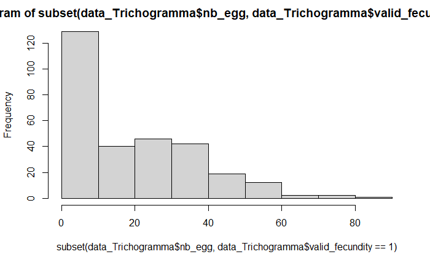

```r
hist(subset(data_Trichogramma$nb_egg, data_Trichogramma$valid_fecundity == 1))
```

```r
mean(subset(data_Trichogramma$nb_egg, data_Trichogramma$valid_fecundity == 1))
```

```
[1] 18.17747
```

```r
var(subset(data_Trichogramma$nb_egg, data_Trichogramma$valid_fecundity == 1))
```

```
[1] 330.9478
```

There is some hints of overdispersion and/or zero-inflation. These are not conclusive (it could be high between-line heterogeneity) but worth considering.

### prior setting

To run our models, we need to specify priors for our three response variables. Priors for random effects and correlation matrices will be standard ones. Priors for the fixed-effects intercepts (species-specific or not) will also be standard for the dispersal models (since these are binary data on a standard 0-1 scale); but they need to be scaled for the fecundity and development time data. We suggest to use the median values as a scaling factor for the priors:

```r
# development time
median(subset(data_Trichogramma$lowbound, data_Trichogramma$valid_development == 1))
```

```
[1] 11
```

```r
# fecundity
median(subset(data_Trichogramma$nb_egg, data_Trichogramma$valid_fecundity == 1))
```

```
[1] 19
```

### Family choice for fecundity

We tried a first univariate negative binomial model for fecundity:

```r
# family choice
bf_fecundity_negbino <- bf(nb_egg | subset(valid_fecundity) ~ 0 + species + (1 | p | line), family = "negbinomial")

# prior setting
prior_fecundity_negbino <- c(
  set_prior("normal(0,1)", class = "sd"),
  set_prior("normal(log(19),1)", class = "b") # the median is on the log scale because of the log link for the negbinomial model
)

# univariate negative binomial model
mod_fecundity_negbino <- brm(
  bf_fecundity_negbino,
  data = data_Trichogramma,
  prior = prior_fecundity_negbino,
  seed = 404,
  warmup = 2000, iter = 4500, chains = 4,
  backend = "cmdstanr"
)
```

There may be some divergences, but we’ll let them pass for now, because:

```r
pp_check(mod_fecundity_negbino, ndraws = 150)
```

[output not shown]

### Main models

**Model 1**

The first model incorporate species as a fixed effect, allowing us to observe inter- and intra- species line covariation:

```r
# priors

prior1 <- c(
  # development priors
  set_prior("normal(log(11),1)", class = "b", resp = "lowbound"),
  set_prior("normal(0,1)", class = "sd", resp = "lowbound"),
  set_prior("normal(0,1)", class = "sigma", resp = "lowbound"),

  # fecundity priors
  set_prior("normal(log(19),1)", class = "b", resp = "nbegg"),
  set_prior("normal(0,1.5)", class = "b", dpar = "zi", resp = "nbegg"),
  set_prior("normal(0,1)", class = "sd", resp = "nbegg"),
  set_prior("normal(0,1)", class = "b", nlpar = "invshape", lb = 0, resp = "nbegg"),

  # dispersal priors
  set_prior("normal(0,1.5)", class = "b", resp = "dispersal"),
  set_prior("normal(0,1)", class = "sd", resp = "dispersal"),

  # covariation
  set_prior("lkj(2)", class = "cor")
)
```

Just like the univariate model, medians are on a log scale to compensate for log-link. Priors for retention probability (`zi` component) and fecundity without retention are all listed under `fecundity priors.`

```r
# formulas

# fecundity
bf_fecundity_0inflated1 <- bf(nb_egg | subset(valid_fecundity) ~ 0 + species + (1 | p | line), # fecundity without 0 inflation
  zi ~ 0 + species + (1 | p | line), # correspond to retention probability
  nlf(shape ~ 1 / invshape),
  invshape ~ 1,
  family = "zero_inflated_negbinomial"(link_shape = "identity")
)

# development time
bf_dvlpmt_cens1 <- bf(lowbound | cens(censore, upbound) + subset(valid_development) ~ 0 + species + (1 | p | line), family = "lognormal")

# dispersal
bf_dispersal1 <- bf(dispersal | subset(valid_dispersal) ~ 0 + species + (1 | p | line), family = "bernoulli")
```

In the fecundity formula, we use invshape so generic priors are easier to set (see https://github.com/stan-dev/stan/wiki/Prior-Choice-Recommendations, the case of negative binomial, for more information), and fixing the link for shape to identity despite the use of a formula (which would otherwise make it default to log link), important for correct prior setting. Development time was interval censored because we do not know when, during the 48h allowed, females really reproduced.

```r
# running model 1

if (file.exists(here("R_output", "model1.Rdata"))) {
  load(here("R_output", "model1.Rdata"))
} else {
  model1 <- brm(
    mvbf(bf_fecundity_0inflated1 + bf_dvlpmt_cens1 + bf_dispersal1),
    data = data_Trichogramma,
    prior = prior1,
    seed = 404,
    warmup = 2000, iter = 4500, chains = 4,
    backend = "cmdstanr"
  )

  save(list = "model1", file = here("R_output", "model1.Rdata"))
}
```

**Model 2**

To be able to more fully describe covariation patterns between lines, the second model removes species-level effects, so removes the partition that was made between within-species and among-species line level covariation. Otherwise, no other changes were made compared to the first model.

```r
# priors

prior2 <- c(
  # development prior
  set_prior("normal(log(11),1)", class = "Intercept", resp = "lowbound"),
  set_prior("normal(0,1)", class = "sd", resp = "lowbound"),
  set_prior("normal(0,1)", class = "sigma", resp = "lowbound"),

  # fecundity prior
  set_prior("normal(log(19),1)", class = "Intercept", resp = "nbegg"),
  set_prior("normal(0,1.5)", class = "Intercept", dpar = "zi", resp = "nbegg"),
  set_prior("normal(0,1)", class = "sd", resp = "nbegg"),
  set_prior("normal(0,1)", class = "b", nlpar = "invshape", lb = 0, resp = "nbegg"),

  # dispersal prior
  set_prior("normal(0,1.5)", class = "Intercept", resp = "dispersal"),
  set_prior("normal(0,1)", class = "sd", resp = "dispersal"),

  # covariation
  set_prior("lkj(2)", class = "cor")
)
```

Removing species slightly changes formulas by removing `0 +` as it is no more necessary to specify that there is no reference species, resulting in a slight change in the prior class (from `class = b` to `class = intercept`).

```r
# formula

bf_fecundity_0inflated2 <- bf(nb_egg | subset(valid_fecundity) ~ (1 | p | line),
  zi ~ (1 | p | line),
  nlf(shape ~ 1 / invshape),
  invshape ~ 1,
  family = "zero_inflated_negbinomial"(link_shape = "identity")
)

bf_dvlpmt_cens2 <- bf(lowbound | cens(censore, upbound) + subset(valid_development) ~ (1 | p | line), family = "lognormal")

bf_dispersal2 <- bf(dispersal | subset(valid_dispersal) ~ (1 | p | line), family = "bernoulli")
```

```r
# running model 2

if (file.exists(here("R_output", "model2.Rdata"))) {
  load(here("R_output", "model2.Rdata"))
} else {
  model2 <- brm(
    mvbf(bf_fecundity_0inflated2 + bf_dvlpmt_cens2 + bf_dispersal2),
    data = data_Trichogramma,
    prior = prior2,
    seed = 404,
    warmup = 2000, iter = 4500, chains = 4,
    backend = "cmdstanr"
  )

  save(list = "model2", file = here("R_output", "model2.Rdata"))
}
```

### various model checks and diagnostics

Now, let’s quickly check models’ results

```r
summary(model1) # check for ESS and Rhat
```

```
 Family: MV(zero_inflated_negbinomial, lognormal, bernoulli)
  Links: mu = log; shape = identity; zi = logit
         mu = identity; sigma = identity
         mu = logit
Formula: nb_egg | subset(valid_fecundity) ~ 0 + species + (1 | p | line)
         zi ~ 0 + species + (1 | p | line)
         shape ~ 1/invshape
         invshape ~ 1
         lowbound | cens(censore, upbound) + subset(valid_development) ~ 0 + species + (1 | p | line)
         dispersal | subset(valid_dispersal) ~ 0 + species + (1 | p | line)
   Data: data_Trichogramma (Number of observations: 790)
  Draws: 4 chains, each with iter = 4500; warmup = 2000; thin = 1;
         total post-warmup draws = 10000

Group-Level Effects:
~line (Number of levels: 28)
                                            Estimate
sd(nbegg_Intercept)                             0.18
sd(zi_nbegg_Intercept)                          0.64
sd(lowbound_Intercept)                          0.04
sd(dispersal_Intercept)                         0.23
cor(nbegg_Intercept,zi_nbegg_Intercept)        -0.22
cor(nbegg_Intercept,lowbound_Intercept)        -0.22
cor(zi_nbegg_Intercept,lowbound_Intercept)      0.20
cor(nbegg_Intercept,dispersal_Intercept)        0.04
cor(zi_nbegg_Intercept,dispersal_Intercept)     0.04
cor(lowbound_Intercept,dispersal_Intercept)     0.12
                                            Est.Error
sd(nbegg_Intercept)                              0.08
sd(zi_nbegg_Intercept)                           0.25
sd(lowbound_Intercept)                           0.01
sd(dispersal_Intercept)                          0.17
cor(nbegg_Intercept,zi_nbegg_Intercept)          0.33
cor(nbegg_Intercept,lowbound_Intercept)          0.30
cor(zi_nbegg_Intercept,lowbound_Intercept)       0.28
cor(nbegg_Intercept,dispersal_Intercept)         0.37
cor(zi_nbegg_Intercept,dispersal_Intercept)      0.36
cor(lowbound_Intercept,dispersal_Intercept)      0.36
                                            l-95% CI
sd(nbegg_Intercept)                             0.02
```

[output cut: 83 more lines]

```
dispersal_speciesbourarachae    -1.54 1.00    17673     6798
dispersal_speciesbrassicae      -1.41 1.00    18808     6992
dispersal_speciesevanescens     -1.53 1.00    18793     7863
dispersal_speciesprincipium     -1.44 1.00    18151     7133
dispersal_speciessemblidis      -0.98 1.00    17753     7782

Family Specific Parameters:
               Estimate Est.Error l-95% CI u-95% CI Rhat
sigma_lowbound     0.05      0.00     0.04     0.06 1.00
               Bulk_ESS Tail_ESS
sigma_lowbound    14061     7987

Draws were sampled using sample(hmc). For each parameter, Bulk_ESS
and Tail_ESS are effective sample size measures, and Rhat is the potential
scale reduction factor on split chains (at convergence, Rhat = 1).
```

```r
summary(model2)
```

```
 Family: MV(zero_inflated_negbinomial, lognormal, bernoulli)
  Links: mu = log; shape = identity; zi = logit
         mu = identity; sigma = identity
         mu = logit
Formula: nb_egg | subset(valid_fecundity) ~ (1 | p | line)
         zi ~ (1 | p | line)
         shape ~ 1/invshape
         invshape ~ 1
         lowbound | cens(censore, upbound) + subset(valid_development) ~ (1 | p | line)
         dispersal | subset(valid_dispersal) ~ (1 | p | line)
   Data: data_Trichogramma (Number of observations: 790)
  Draws: 4 chains, each with iter = 4500; warmup = 2000; thin = 1;
         total post-warmup draws = 10000

Group-Level Effects:
~line (Number of levels: 28)
                                            Estimate
sd(nbegg_Intercept)                             0.32
sd(zi_nbegg_Intercept)                          0.74
sd(lowbound_Intercept)                          0.06
sd(dispersal_Intercept)                         0.26
cor(nbegg_Intercept,zi_nbegg_Intercept)         0.08
cor(nbegg_Intercept,lowbound_Intercept)        -0.62
cor(zi_nbegg_Intercept,lowbound_Intercept)     -0.17
cor(nbegg_Intercept,dispersal_Intercept)        0.19
cor(zi_nbegg_Intercept,dispersal_Intercept)     0.15
cor(lowbound_Intercept,dispersal_Intercept)    -0.08
                                            Est.Error
sd(nbegg_Intercept)                              0.07
sd(zi_nbegg_Intercept)                           0.23
sd(lowbound_Intercept)                           0.01
sd(dispersal_Intercept)                          0.18
cor(nbegg_Intercept,zi_nbegg_Intercept)          0.28
cor(nbegg_Intercept,lowbound_Intercept)          0.17
cor(zi_nbegg_Intercept,lowbound_Intercept)       0.25
cor(nbegg_Intercept,dispersal_Intercept)         0.35
cor(zi_nbegg_Intercept,dispersal_Intercept)      0.35
cor(lowbound_Intercept,dispersal_Intercept)      0.34
                                            l-95% CI
sd(nbegg_Intercept)                             0.20
```

[output cut: 51 more lines]

```
nbegg_Intercept              3.42 1.00     6266     7270
zi_nbegg_Intercept          -0.40 1.00     8386     7832
lowbound_Intercept           2.53 1.00     6225     6392
dispersal_Intercept         -1.73 1.00    13129     7236
nbegg_invshape_Intercept     0.47 1.00    13138     7669

Family Specific Parameters:
               Estimate Est.Error l-95% CI u-95% CI Rhat
sigma_lowbound     0.05      0.00     0.04     0.06 1.00
               Bulk_ESS Tail_ESS
sigma_lowbound    12941     7306

Draws were sampled using sample(hmc). For each parameter, Bulk_ESS
and Tail_ESS are effective sample size measures, and Rhat is the potential
scale reduction factor on split chains (at convergence, Rhat = 1).
```

[figure not shown]

[figure not shown]

[figure not shown]

[figure not shown]

[figure not shown]

[figure not shown]

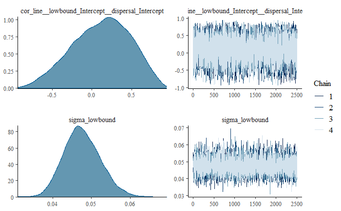

```r
# convergence/stationarity checks
plot(model1) # MCMC seem to overlap nicely
```

[figure not shown]

[figure not shown]

[figure not shown]

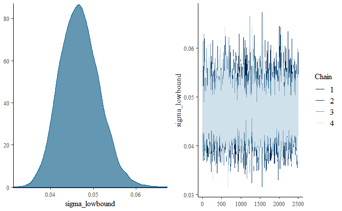

```r
plot(model2)
```

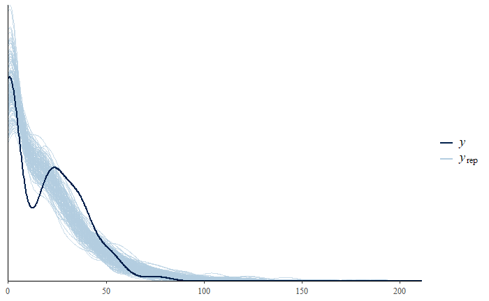

```r
# fecundity:
pp_check(model1, resp = "nbegg", ndraws = 150) # follows the curve but fails to correctly present the dip between ZI and mean fecundity
```

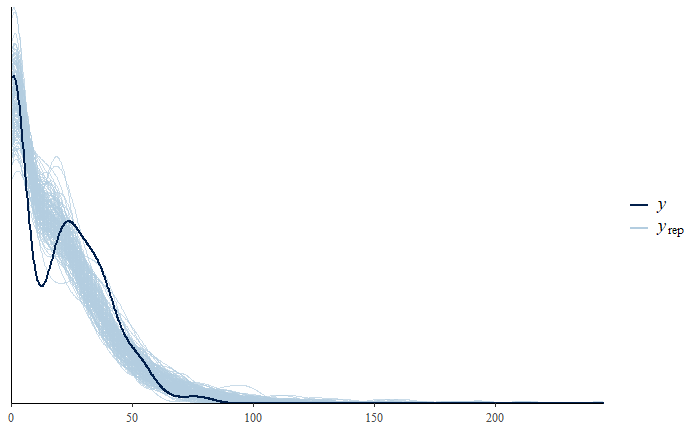

```r
# but it does capture the correct % of zeroes
## note: if you re-run the model using a ZI Poisson instead, the dip is better but the model performs way worse in other aspects (model comparison using WAIC/LOO), reflecting existing overdispersion. So that's probably as good as one can get without more information (prior or data)
pp_check(model2, resp = "nbegg", ndraws = 150)
```

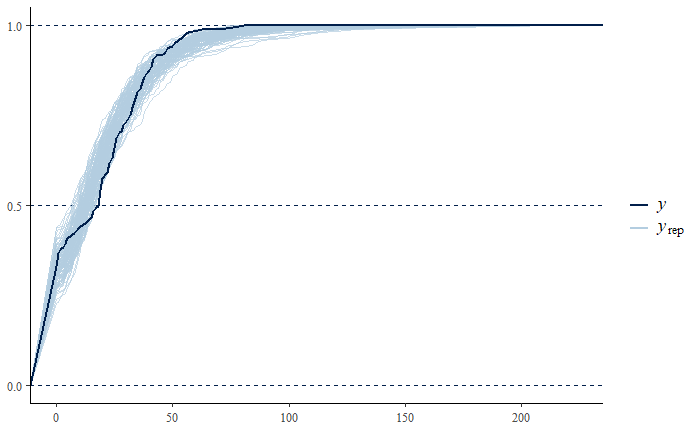

```r
pp_check(model1, resp = "nbegg", type = "ecdf_overlay", ndraws = 150)
```

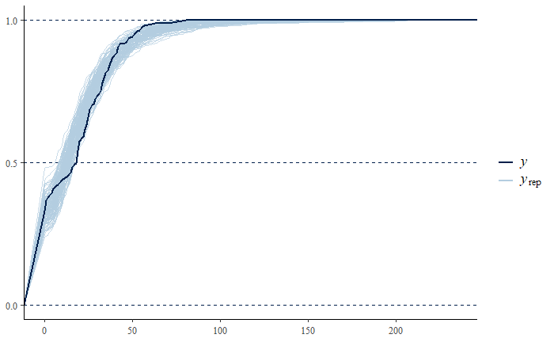

```r
pp_check(model2, resp = "nbegg", type = "ecdf_overlay", ndraws = 150)
```

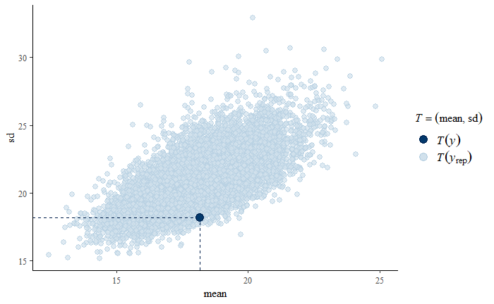

```r
pp_check(model1, resp = "nbegg", type = "stat_2d")
```

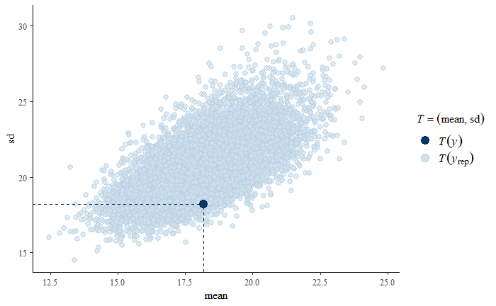

```r
pp_check(model2, resp = "nbegg", type = "stat_2d")
```

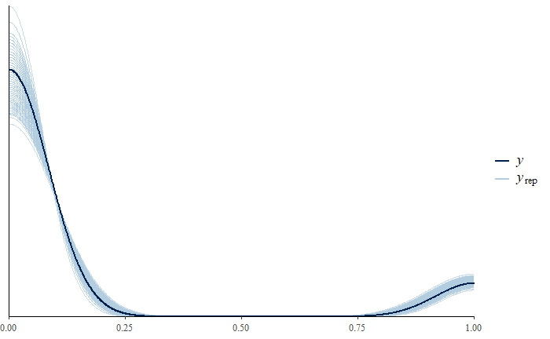

```r
# dispersal (but due to binary type, unlikely to be very informative, most checks should always perform well)
pp_check(model1, resp = "dispersal", ndraws = 150)
```

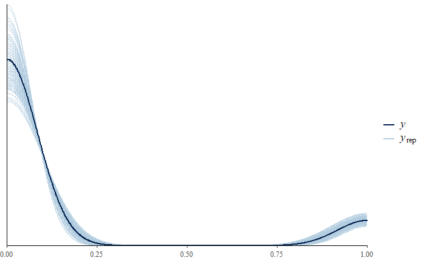

```r
pp_check(model2, resp = "dispersal", ndraws = 150)
```

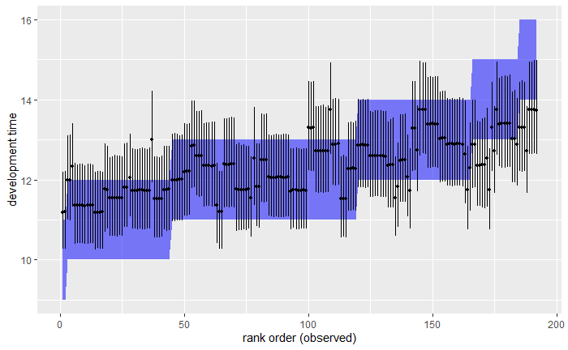

```r
# development time

# there are no good simple way to use pp_check for interval censored data.
# but we can get *some* information by being creative

source <- data_Trichogramma |>
  filter(valid_development == 1)

yrep1 <- posterior_predict(model1, resp = "lowbound", summary = FALSE) # posterior predictive distribution of data

ppc_intervals_data(source$lowbound, yrep = yrep1) |>
  mutate(lowbound_obs = y_obs, upbound_obs = source$upbound) |>
  arrange(lowbound_obs) |>
  mutate(x = row_number()) |>
  ggplot() +
  geom_ribbon(aes(x, ymin = lowbound_obs, ymax = upbound_obs), fill = "blue", alpha = 0.5) +
  geom_pointinterval(aes(x, y = m, ymin = ll, ymax = hh)) +
  scale_y_continuous("development time") +
  scale_x_continuous("rank order (observed)")
```

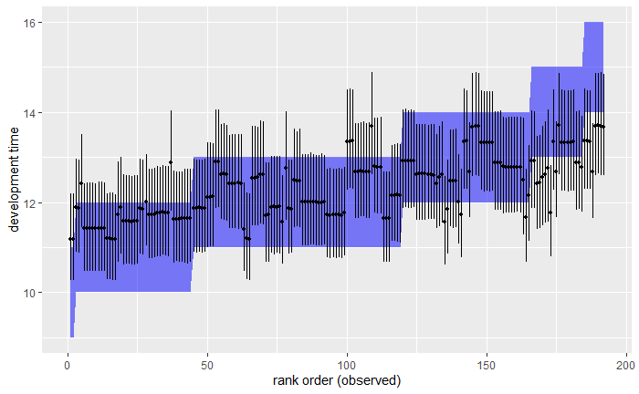

```r
# in this plot the ribbon denotes the observed data (the 2 day interval)
# and the points and error bars represents the posterior mean prediction and CI95 (quantile interval)
# we can see that the model does a decent job at matching the data (not many points are outside the observed range, and for the majority of the predictions where the point/mean is outside the observed range, the CI is comfortably overlapping it)

yrep2 <- posterior_predict(model2, resp = "lowbound", summary = FALSE) # posterior predictive distribution of data

ppc_intervals_data(source$lowbound, yrep = yrep2) |>
  mutate(lowbound_obs = y_obs, upbound_obs = source$upbound) |>
  arrange(lowbound_obs) |>
  mutate(x = row_number()) |>
  ggplot() +
  geom_ribbon(aes(x, ymin = lowbound_obs, ymax = upbound_obs), fill = "blue", alpha = 0.5) +
  geom_pointinterval(aes(x, y = m, ymin = ll, ymax = hh)) +
  scale_y_continuous("development time") +
  scale_x_continuous("rank order (observed)")
```

```r
# Building on this, one can probably think of other ways to check that the model does well for development time, despite the interval censoring barrier
```

## predictions and plots

### generation

We create posterior datasets for the 2 models

```r
# Create posterior dataset for the first model

unique_lines <- data_Trichogramma |>
  select(species, line) |>
  distinct() |>
  mutate(valid_development = 1, valid_dispersal = 1, valid_fecundity = 1)

# development dataset
modcens1_data_dvlp <- unique_lines |>
  add_epred_draws(model1, resp = "lowbound") |>
  rename(development_time = .epred)

# dispersal
modcens1_data_disp <- unique_lines |>
  add_epred_draws(model1, resp = "dispersal") |>
  rename(dispersal_probability = .epred)

# fecundity
modcens1_data_fec <- unique_lines |>
  add_epred_draws(model1, resp = "nbegg", dpar = c("zi", "mu")) |>
  rename(fecundity = .epred)
# mu ccorrespond to the fecundity of individuals without retention

# fuse all response posterior datasets into one unique dataset
model1_data <- modcens1_data_dvlp |>
  left_join(modcens1_data_disp) |>
  left_join(modcens1_data_fec) |>
  subset(select = -c(.iteration, .chain, .row, valid_development, valid_dispersal, valid_fecundity))


# the same is done for model 2
modcens2_data_dvlp <- unique_lines |>
  add_epred_draws(model2, resp = "lowbound") |>
  rename(development_time = .epred)


modcens2_data_disp <- unique_lines |>
  add_epred_draws(model2, resp = "dispersal") |>
  rename(dispersal_probability = .epred)


modcens2_data_fec <- unique_lines |>
  add_epred_draws(model2, resp = "nbegg", dpar = c("zi", "mu")) |>
  rename(fecundity = .epred)

# fusing all posteriors into one dataset for model 2
model2_data <- modcens2_data_dvlp |>
  left_join(modcens2_data_disp) |>
  left_join(modcens2_data_fec) |>
  subset(select = -c(.iteration, .chain, .row, valid_development, valid_dispersal, valid_fecundity))
```

To later study only species-level trait values, we also extracted only fixed effect posterior values. This step is only possible on the first model, as it is the only one accounting for species.

```r
unique_species <- data_Trichogramma |>
  select(species) |>
  distinct() |>
  mutate(valid_development = 1, valid_dispersal = 1, valid_fecundity = 1)

fixed_data_dvlp <- unique_species |>
  add_epred_draws(model1, resp = "lowbound", re_formula = NA) |>
  rename(development_time = .epred)


fixed_data_disp <- unique_species |>
  add_epred_draws(model1, resp = "dispersal", re_formula = NA) |>
  rename(dispersal_probability = .epred)


fixed_data_fec <- unique_species |>
  add_epred_draws(model1, resp = "nbegg", dpar = c("zi", "mu"), re_formula = NA) |>
  rename(fecundity = .epred)


fixed_data <- fixed_data_dvlp |>
  left_join(fixed_data_disp) |>
  left_join(fixed_data_fec) |>
  subset(select = -c(.iteration, .chain, .row, valid_development, valid_dispersal, valid_fecundity))
```

### Table 1: species level (fixed effects) predictions, summary table

This code is used to get 95% highest density intervals for species level trait values. Decimal numbers are rounded to two decimal places.

```r
table_trait_values_development <- fixed_data |>
  group_by(species) |>
  mean_hdi(development_time) |>
  mutate(development_time = paste(round(development_time, 2), " [", round(.lower, 2), "; ", round(.upper, 2), "]", sep = "")) |>
  select(-c(.lower, .upper, .width, .point, .interval))

table_trait_values_fecundity <- fixed_data |>
  group_by(species) |>
  mean_hdi(mu) |>
  mutate(fecundity_no_retention = paste(round(mu, 2), " [", round(.lower, 2), "; ", round(.upper, 2), "]", sep = "")) |>
  select(-c(.lower, .upper, .width, .point, .interval, mu))

table_trait_values_retention <- fixed_data |>
  group_by(species) |>
  mean_hdi(zi) |>
  mutate(retention_probability = paste(round(zi, 2), " [", round(.lower, 2), "; ", round(.upper, 2), "]", sep = "")) |>
  select(-c(.lower, .upper, .width, .point, .interval, zi))

table_trait_values_dispersal <- fixed_data |>
  group_by(species) |>
  mean_hdi(dispersal_probability) |>
  mutate(dispersal_probability = paste(round(dispersal_probability, 2), " [", round(.lower, 2), "; ", round(.upper, 2), "]", sep = "")) |>
  select(-c(.lower, .upper, .width, .point, .interval))


table1 <- left_join(table_trait_values_development, table_trait_values_fecundity) |>
  left_join(table_trait_values_retention) |>
  left_join(table_trait_values_dispersal)
table1
```

| species | development_time | fecundity_no_retention | retention_probability | dispersal_probability |
| --- | --- | --- | --- | --- |
| bourarachae | 13.3 [12.64; 13.97] | 17.42 [12.77; 22.5] | 0.17 [0.05; 0.32] | 0.09 [0.03; 0.16] |
| brassicae | 11.79 [11.4; 12.2] | 35.24 [27.71; 42.7] | 0.38 [0.24; 0.51] | 0.14 [0.08; 0.19] |
| evanescens | 12.47 [11.94; 12.96] | 24.31 [18.43; 30.49] | 0.28 [0.14; 0.43] | 0.11 [0.05; 0.17] |
| principium | 12.69 [11.95; 13.42] | 20.49 [13.83; 27.71] | 0.32 [0.13; 0.53] | 0.1 [0.03; 0.18] |
| semblidis | 11.97 [11.39; 12.52] | 30.02 [21.42; 39.2] | 0.47 [0.27; 0.65] | 0.18 [0.1; 0.27] |

### pairwise differences between species (for “significantly different” markers on figure 2)

```r
species_compare <- fixed_data |>
  pivot_longer(cols = c(development_time, dispersal_probability, fecundity, zi, mu), names_to = "trait") |>
  group_by(trait) |>
  compare_levels(variable = value, by = species) |>
  group_by(trait, species) |>
  mean_hdi()

print(species_compare, n = Inf)

# one can also do it by line (commented out because takes some time, there are a lot of pairwise comparisons between 28 lines)
# lines_compare <- model1_data |>
#  pivot_longer(cols=c(development_time,dispersal_probability,fecundity,zi,mu), names_to = "trait") |>
#  group_by(trait) |>
#  compare_levels(variable=value,by=line) |>
#  group_by(trait,line) |>
#  mean_hdi()
```

[output not shown]

### Figure 2: species and line level posterior per trait

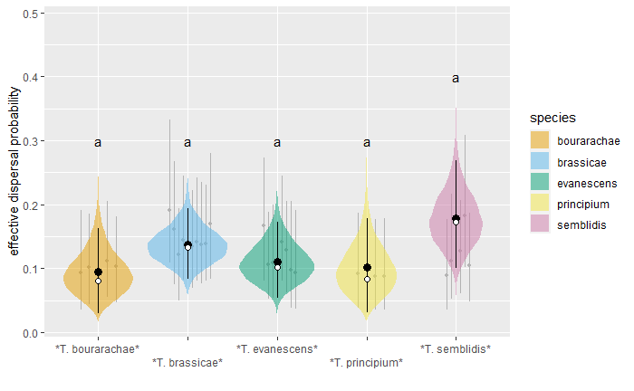

```r
# colourblind-friendly palette for species
species_palette <- c("#E69F00", "#56B4E9", "#009E73", "#F0E442", "#CC79A7")

# plot position for lines posteriors, to make sure that no lines are hidden by species posterior
position_lines <- c(0.8,0.9,1.1,1.2,1.8,1.85,1.9,1.95,2.05,2.1,2.15,2.2,2.25,2.85,2.9,2.95,3.05,3.1,3.15,3.2,3.9,4.1,4.2,4.9,4.95,5.05,5.1,5.15)

# sorting lines in order of the graphical representation
model1_data <- model1_data |>
  arrange(species) |>
  group_by(species) |>
  arrange (line, .by_group = TRUE)

model1_data$full_species <- paste0("*T. ", model1_data$species, "*")
fixed_data$full_species <- paste0("*T. ", fixed_data$species, "*")

## observed means for plotting (approximated for development and fecundity variables)
observed_species_disp <- data_Trichogramma |>
  filter(valid_dispersal == 1) |>
  group_by(species) |>
  summarise(disp = mean(dispersal)) |>
  mutate(full_species = paste0("*T. ", species, "*"))

observed_species_dev <- data_Trichogramma |>
  filter(valid_development == 1) |>
  group_by(species) |>
  summarise(time = mean((upbound + lowbound) / 2)) |>
  mutate(full_species = paste0("*T. ", species, "*"))

observed_species_zi <- data_Trichogramma |>
  filter(valid_fecundity == 1) |>
  group_by(species) |>
  summarise(zi = mean(nb_egg == 0)) |>
  mutate(full_species = paste0("*T. ", species, "*"))

observed_species_mu <- data_Trichogramma |>
  filter(valid_development == 1 & nb_egg > 0) |>
  group_by(species) |>
  summarise(mu = mean(nb_egg)) |>
  mutate(full_species = paste0("*T. ", species, "*"))


# creating one plot for each trait, using the ordered dataset from the first model posterior values
plot_dispersal <- ggplot() +
  stat_pointinterval(
    data = model1_data,
    aes(full_species, dispersal_probability, group = line),
    col = "grey70",
    x = position_lines,
    .width = 0.95
  ) +
  stat_eye(
    data = fixed_data,
    aes(full_species, dispersal_probability, fill = species),
    slab_alpha = 0.5,
    .width = c(0.001, 0.95),
    point_interval = "mean_hdi"
  ) +
  geom_point(
    data = observed_species_disp,
    aes(full_species, disp), pch = 21, fill = "white", size = 2
  )  +
  scale_fill_manual(values = species_palette) +
  scale_x_discrete("", guide = guide_axis(n.dodge = 2)) +
  scale_y_continuous("effective dispersal probability") +
  annotate("text", x=1, y=0.3, label= "a") +
  annotate("text", x=2, y=0.3, label= "a") +
  annotate("text", x=3, y=0.3, label= "a") +
  annotate("text", x=4, y=0.3, label= "a") +
  annotate("text", x=5, y=0.4, label= "a") +
  coord_cartesian(xlim = c(1, 5))


plot_dispersal
```

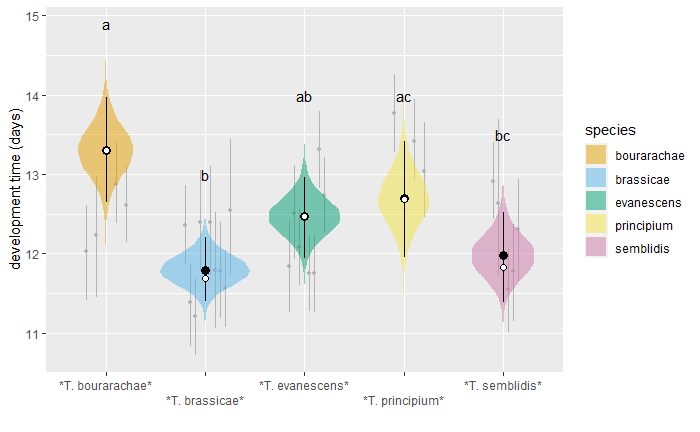

```r
plot_development <- ggplot() +
  stat_pointinterval(
    data = model1_data,
    aes(full_species, development_time, group = line),
    col = "grey70",
    x = position_lines,
    .width = 0.95
  ) +
  stat_eye(
    data = fixed_data,
    aes(full_species, development_time, fill = species),
    slab_alpha = 0.5,
    .width = c(0.001, 0.95),
    point_interval = "mean_hdi"
  ) +
  geom_point(
    data = observed_species_dev,
    aes(full_species, time), pch = 21, fill = "white", size = 2
  ) +
  scale_fill_manual(values = species_palette) +
  scale_x_discrete("", guide = guide_axis(n.dodge = 2)) +
  scale_y_continuous("development time (days)") +
  annotate("text", x=1, y=14.9, label= "a") +
  annotate("text", x=2, y=13, label= "b") +
  annotate("text", x=3, y=14, label= "ab") +
  annotate("text", x=4, y=14, label= "ac") +
  annotate("text", x=5, y=13.5, label= "bc") +
  coord_cartesian(xlim = c(1, 5))

plot_development
```

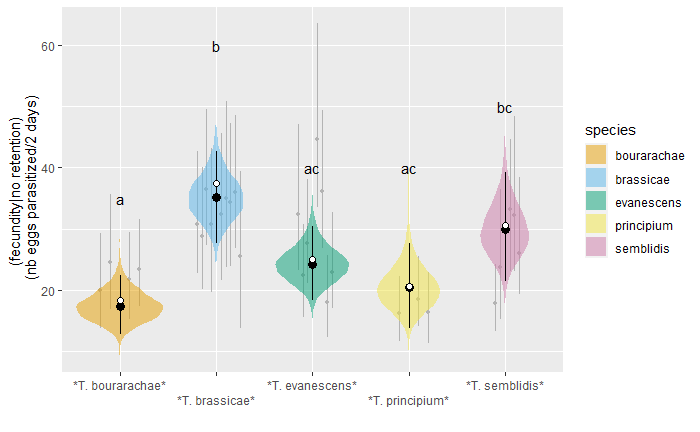

```r
plot_fecundity <- ggplot() +
  stat_pointinterval(
    data = model1_data,
    aes(full_species, mu, group = line),
    col = "grey70",
    x = position_lines,
    .width = 0.95
  ) +
  stat_eye(
    data = fixed_data,
    aes(full_species, mu, fill = species),
    slab_alpha = 0.5,
    .width = c(0.001, 0.95),
    point_interval = "mean_hdi"
  ) +
  geom_point(
    data = observed_species_mu,
    aes(full_species, mu), pch = 21, fill = "white", size = 2
  ) +
  scale_fill_manual(values = species_palette) +
  scale_x_discrete("", guide = guide_axis(n.dodge = 2)) +
  scale_y_continuous("(fecundity|no retention) \n (nb eggs parasitized/2 days)")+
  annotate("text", x=1, y=35, label= "a") +
  annotate("text", x=2, y=60, label= "b") +
  annotate("text", x=3, y=40, label= "ac") +
  annotate("text", x=4, y=40, label= "ac") +
  annotate("text", x=5, y=50, label= "bc") +
  coord_cartesian(xlim = c(1, 5))

plot_fecundity
```

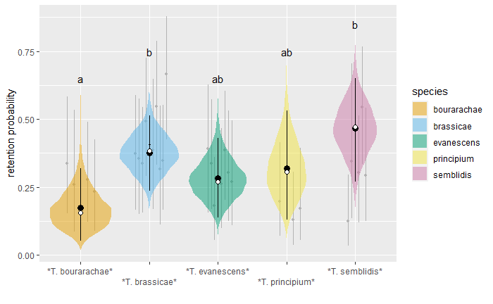

```r
plot_zi <- ggplot() +
  stat_pointinterval(
    data = model1_data,
    aes(full_species, zi, group = line),
    col = "grey70",
    x = position_lines,
    .width = 0.95
  ) +
  stat_eye(
    data = fixed_data,
    aes(full_species, zi, fill = species),
    slab_alpha = 0.5,
    .width = c(0.001, 0.95),
    point_interval = "mean_hdi"
  ) +
  geom_point(
    data = observed_species_zi,
    aes(full_species, zi), pch = 21, fill = "white", size = 2
  ) +
  scale_fill_manual(values = species_palette) +
  scale_x_discrete("", guide = guide_axis(n.dodge = 2)) +
  scale_y_continuous("retention probability") +
  annotate("text", x = 1, y = 0.65, label = "a") +
  annotate("text", x = 2, y = 0.75, label = "b") +
  annotate("text", x = 3, y = 0.65, label = "ab") +
  annotate("text", x = 4, y = 0.75, label = "ab") +
  annotate("text", x = 5, y = 0.85, label = "b") +
  coord_cartesian(xlim = c(1, 5))

plot_zi
```

```r
# fuse all plots in one
fig2 <- (plot_dispersal / plot_development / plot_fecundity / plot_zi) &
  theme_bw() &
  theme(legend.position = "none", axis.text.x = element_markdown()) &
  plot_annotation(tag_levels = "A")
```

[output not shown]

[figure not shown]

```r
fig2
```

```r
# you can save generated figures in 'figures' folder, at the right dimensions using the commented code below:

# ggsave(here("figures", "fig2.pdf"), width = 163, height = 230, dpi = 1200, units = "mm")
# ggsave(here("figures", "fig2.png"), width = 163, height = 230, dpi = 1200, units = "mm")
```

### Figure 3: correlation between development time and fecundity without retention

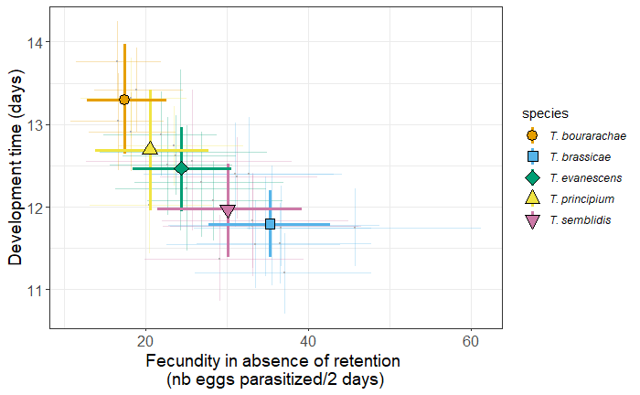

```r
# first create a table for species highest density interval (fixed effect only)
figure_POL_mu <- fixed_data |>
  group_by(species) |>
  mean_hdi(mu) |> # 95 highest density interval (.width = 0.95)
  rename(mu.lower = .lower) |>
  rename(mu.upper = .upper)

figure_POL_development <- fixed_data |>
  group_by(species) |>
  mean_hdi(development_time) |>
  rename(development.lower = .lower) |>
  rename(development.upper = .upper)

figure_POL_species <- figure_POL_development |>
  left_join(figure_POL_mu) |>
  mutate(full_species = paste0("*T. ", species, "*"))
# then a table for lines highest density intervals
figure_POL_mu <- model1_data |>
  group_by(species, line) |>
  mean_hdi(mu) |>
  rename(mu.lower = .lower) |>
  rename(mu.upper = .upper)

figure_POL_development <- model1_data |>
  group_by(species, line) |>
  mean_hdi(development_time) |>
  rename(development.lower = .lower) |>
  rename(development.upper = .upper)

figure_POL_line <- figure_POL_development |>
  left_join(figure_POL_mu) |>
  mutate(full_species = paste0("*T. ", species, "*"))
# the plot
ggplot(data = figure_POL_line) +
  geom_linerange(
    aes(
      y = development_time, x = mu,
      ymin = development.lower, ymax = development.upper , colour = full_species
    ),
    size = 0.5, alpha = 0.3
  ) +
  geom_linerange(
    aes(
      y = development_time, x = mu,
      xmin = mu.lower, xmax = mu.upper , colour = full_species
    ),
    size = 0.5, alpha = 0.3
  ) +
  geom_point(aes(y = development_time, x = mu), size = 0.5) +
  geom_point(aes(y = development_time, x = mu), size = 0.5, colour = "grey70") +
  geom_linerange(
    data = figure_POL_species,
    aes(
      y = development_time, x = mu,
      ymin = development.lower, ymax = development.upper,
      col = full_species
    ), size = 1.1
  ) +
  geom_linerange(
    data = figure_POL_species,
    aes(
      y = development_time, x = mu,
      xmin = mu.lower, xmax = mu.upper,
      col = full_species
    ), size = 1.1
  ) +
  geom_point(data = figure_POL_species, mapping = aes(
    y = development_time, x = mu, fill = full_species,
    pch = full_species
  ), size = 4, colour = "black") +
  xlab("Fecundity in absence of retention \n(nb eggs parasitized/2 days)") +
  ylab("Development time (days)") +
  labs(fill = "species", col = "species", shape = "species") +
  scale_color_manual(values = c(species_palette, species_palette)) +
  scale_fill_manual(values = c(species_palette, species_palette)) +
  scale_shape_manual(values = 21:25) +
  theme_bw() +
  theme(
    axis.text = element_text(size = 12),
    axis.title = element_text(size = 14),
    legend.text = element_markdown()
  )

# you can save generated figures in 'figures' folder, at the right dimensions using the commented code below:

 ggsave(here("figures", "fig3_v2.pdf"), width = 152, height = 108, dpi = 1200, units = "mm")
```

```r
# ggsave(here("figures", "fig3_v2.png"), width = 152, height = 108, dpi = 1200, units = "mm")
```

```r
# create summaries for the two models, with HDI credible intervals rather than the default quantile intervals of summary()

summary_model1 <- model1 |>
  as_draws_df() |>
  select(starts_with("cor_")) |>
  pivot_longer(everything()) |>
  group_by(name) |>
  mean_hdi()
summary_model1 |>
  print(n = Inf)
```

| name | value | .lower | .upper | .width | .point | .interval |
| --- | --- | --- | --- | --- | --- | --- |
| Cor_1[1,1] | 1.00000000 | 1.000000 | 1.000000 | 0.95 | mean | hdi |
| Cor_1[1,2] | -0.22158605 | -0.854017 | 0.404902 | 0.95 | mean | hdi |
| Cor_1[1,3] | -0.21808619 | -0.760573 | 0.375362 | 0.95 | mean | hdi |
| Cor_1[1,4] | 0.03691364 | -0.662468 | 0.717486 | 0.95 | mean | hdi |
| Cor_1[2,1] | -0.22158605 | -0.854017 | 0.404902 | 0.95 | mean | hdi |
| Cor_1[2,2] | 1.00000000 | 1.000000 | 1.000000 | 0.95 | mean | hdi |
| Cor_1[2,3] | 0.19739596 | -0.365064 | 0.713968 | 0.95 | mean | hdi |
| Cor_1[2,4] | 0.03759259 | -0.646823 | 0.729685 | 0.95 | mean | hdi |
| Cor_1[3,1] | -0.21808619 | -0.760573 | 0.375362 | 0.95 | mean | hdi |
| Cor_1[3,2] | 0.19739596 | -0.365064 | 0.713968 | 0.95 | mean | hdi |

[output cut: 12 more lines]

```r
summary_model2 <- model2 |>
  as_draws_df() |>
  select(starts_with("cor_")) |>
  pivot_longer(everything()) |>
  group_by(name) |>
  mean_hdi()
summary_model2 |>
  print(n = Inf)
```

| name | value | .lower | .upper | .width | .point | .interval |
| --- | --- | --- | --- | --- | --- | --- |
| Cor_1[1,1] | 1.00000000 | 1.000000 | 1.000000 | 0.95 | mean | hdi |
| Cor_1[1,2] | 0.07681432 | -0.476999 | 0.607103 | 0.95 | mean | hdi |
| Cor_1[1,3] | -0.61846277 | -0.920540 | -0.284734 | 0.95 | mean | hdi |
| Cor_1[1,4] | 0.19348756 | -0.464701 | 0.820320 | 0.95 | mean | hdi |
| Cor_1[2,1] | 0.07681432 | -0.476999 | 0.607103 | 0.95 | mean | hdi |
| Cor_1[2,2] | 1.00000000 | 1.000000 | 1.000000 | 0.95 | mean | hdi |
| Cor_1[2,3] | -0.16608098 | -0.641059 | 0.311137 | 0.95 | mean | hdi |
| Cor_1[2,4] | 0.15498216 | -0.520522 | 0.806637 | 0.95 | mean | hdi |
| Cor_1[3,1] | -0.61846277 | -0.920540 | -0.284734 | 0.95 | mean | hdi |
| Cor_1[3,2] | -0.16608098 | -0.641059 | 0.311137 | 0.95 | mean | hdi |

[output cut: 12 more lines]

```r
# model 1: correlations partitioned into among-species and within species components, so the random effect correlation table only reflect within species correlation

table_cor_LINE <- summary_model1 |>
  mutate(value = paste(round(value, 2), " [", round(.lower, 2), "; ", round(.upper, 2), "]", sep = "")) |>
  filter(str_detect(name, "cor_line") == TRUE) |>
  mutate(
    response1 = case_when(
      str_detect(name, "cor_line__lowbound") ~ "lowbound",
      str_detect(name, "cor_line__zi") ~ "retention_probability",
      str_detect(name, "cor_line__nbegg") ~ "fecundity_noretention",
      str_detect(name, "cor_line__dispersal") ~ "dispersal_probability"
    ),
    response2 = case_when(
      str_detect(name, "lowbound_Intercept$") ~ "lowbound",
      str_detect(name, "zi_nbegg_Intercept$") ~ "retention_probability",
      str_detect(name, "nbegg_Intercept$") ~ "fecundity_noretention",
      str_detect(name, "dispersal_Intercept$") ~ "dispersal_probability"
    ),
  ) |>
  select(response1, response2, value)

# first model table
table_cor_LINE
```

| response1 | response2 | value |
| --- | --- | --- |
| lowbound | dispersal_probability | 0.12 [-0.58; 0.79] |
| fecundity_noretention | dispersal_probability | 0.04 [-0.66; 0.72] |
| fecundity_noretention | lowbound | -0.22 [-0.76; 0.38] |
| fecundity_noretention | retention_probability | -0.22 [-0.85; 0.4] |
| retention_probability | dispersal_probability | 0.04 [-0.65; 0.73] |
| retention_probability | lowbound | 0.2 [-0.37; 0.71] |

```r
# model 2: covariation is not partitioned into among-species and within species components

table_cor_fullLINE <- summary_model2 |>
  mutate(value = paste(round(value, 2), " [", round(.lower, 2), "; ", round(.upper, 2), "]", sep = "")) |>
  filter(str_detect(name, "cor_line") == TRUE) |>
  mutate(
    response1 = case_when(
      str_detect(name, "cor_line__lowbound") ~ "development_time",
      str_detect(name, "cor_line__zi") ~ "retention_probability",
      str_detect(name, "cor_line__nbegg") ~ "fecundity_noretention",
      str_detect(name, "cor_line__dispersal") ~ "dispersal_probability"
    ),
    response2 = case_when(
      str_detect(name, "lowbound_Intercept$") ~ "development_time",
      str_detect(name, "zi_nbegg_Intercept$") ~ "retention_probability",
      str_detect(name, "nbegg_Intercept$") ~ "fecundity_noretention",
      str_detect(name, "dispersal_Intercept$") ~ "dispersal_probability"
    ),
  ) |>
  select(response1, response2, value)


## second model table
table_cor_fullLINE
```

| response1 | response2 | value |
| --- | --- | --- |
| development_time | dispersal_probability | -0.08 [-0.71; 0.59] |
| fecundity_noretention | dispersal_probability | 0.19 [-0.46; 0.82] |
| fecundity_noretention | development_time | -0.62 [-0.92; -0.28] |
| fecundity_noretention | retention_probability | 0.08 [-0.48; 0.61] |
| retention_probability | dispersal_probability | 0.15 [-0.52; 0.81] |
| retention_probability | development_time | -0.17 [-0.64; 0.31] |